# Model Selection

Jonathan Cárdenas

2023-03-12

# 1. Dataset upload and data set splitting

Uploading the original dataset (raw data):

## 1.1 Separate dataset to use image derived features as predictors.

Create 6 data frames based on the raw data: Source: Metadata, predictors and all response variables (raw_data).  
1) Image derived predictors and all response variables. 2) Manual predictors and all response variables. 3) Image derived predictors and LFW 4) Image derived predictors and LDW 5) Image derived predictors and LA

# 2. Model Selection and Performance

Fit different models to estimate 3 biomass variables (LFW,LDW,LA). Our baseline comparison (Model 0) will be a multiple linear regression model chose by using AIC and BIC criteria.

## Model 0: Multiple Linear Regression.

### Estimation of Leaf Fresh Weight (LFW)

```
## Start:  AIC=1337.26
## LFW_g ~ 1
##
##                              Df Sum of Sq    RSS     AIC
## + plant_ellipse_minor_axis    1    498073  41458  915.87
## + height_mm                   1    489314  50217  947.50
## + plant_area                  1    466937  72594 1008.30
## + plant_height                1    463135  76396 1016.73
## + plant_width                 1    437259 102272 1064.86
## + plant_convex_hull_area      1    430538 108993 1075.36
## + plant_longest_path          1    420483 119048 1089.92
## + plant_ellipse_major_axis    1    417716 121815 1093.71
## + plant_convex_hull_vertices  1    405459 134072 1109.53
## + plant_perimeter             1    353613 185918 1163.47
## + plant_solidity              1     62080 477451 1319.09
## + plant_ellipse_eccentricity  1     47604 491927 1324.02
## <none>                                    539531 1337.26
## + plant_ellipse_angle         1        87 539444 1339.24
##
## Step:  AIC=915.87
## LFW_g ~ plant_ellipse_minor_axis
##
##                              Df Sum of Sq   RSS    AIC
## + height_mm                   1    3210.8 38248 904.57
## + plant_area                  1    2504.9 38953 907.59
## + plant_ellipse_eccentricity  1    1318.5 40140 912.54
## + plant_solidity              1    1068.4 40390 913.56
## + plant_convex_hull_area      1     819.4 40639 914.58
## <none>                                    41458 915.87
## + plant_perimeter             1     408.6 41050 916.24
## + plant_ellipse_angle         1     290.1 41168 916.71
## + plant_convex_hull_vertices  1     119.7 41339 917.39
## + plant_height                1     100.0 41358 917.47
## + plant_width                 1      31.4 41427 917.75
## + plant_longest_path          1       0.8 41457 917.87
## + plant_ellipse_major_axis    1       0.1 41458 917.87
##
## Step:  AIC=904.57
## LFW_g ~ plant_ellipse_minor_axis + height_mm
##
```

[output cut: 58 more lines]

```
## + plant_width                 1      2.44 17097 779.71
##
## Step:  AIC=774.16
## LFW_g ~ plant_ellipse_minor_axis + height_mm + plant_area + plant_ellipse_major_axis +
##     plant_ellipse_eccentricity + plant_convex_hull_area
##
##                              Df Sum of Sq   RSS    AIC
## <none>                                    16531 774.16
## + plant_longest_path          1   165.476 16366 774.50
## + plant_solidity              1    81.131 16450 775.35
## + plant_perimeter             1    64.267 16467 775.52
## + plant_convex_hull_vertices  1    63.148 16468 775.53
## + plant_height                1    53.501 16478 775.63
## + plant_width                 1    30.637 16500 775.86
## + plant_ellipse_angle         1     5.237 16526 776.11
```

```
##
## Call:
## lm(formula = LFW_g ~ plant_ellipse_minor_axis + height_mm + plant_area +
##     plant_ellipse_major_axis + plant_ellipse_eccentricity + plant_convex_hull_area,
##     data = img_LFW)
##
## Residuals:
##     Min      1Q  Median      3Q     Max
## -31.281  -4.943  -0.767   5.011  37.571
##
## Coefficients:
##                              Estimate Std. Error t value Pr(>|t|)
## (Intercept)                -4.516e+01  7.864e+00  -5.743 4.64e-08 ***
## plant_ellipse_minor_axis    3.057e-01  1.246e-01   2.453   0.0153 *
## height_mm                   7.642e+00  8.484e-01   9.007 6.50e-16 ***
## plant_area                  4.374e-03  9.846e-04   4.442 1.67e-05 ***
## plant_ellipse_major_axis   -1.049e+00  1.071e-01  -9.797  < 2e-16 ***
## plant_ellipse_eccentricity  4.935e+01  1.072e+01   4.602 8.55e-06 ***
## plant_convex_hull_area      2.058e-03  8.835e-04   2.330   0.0211 *
## ---
## Signif. codes:  0 '***' 0.001 '**' 0.01 '*' 0.05 '.' 0.1 ' ' 1
##
## Residual standard error: 10.23 on 158 degrees of freedom
## Multiple R-squared:  0.9694, Adjusted R-squared:  0.9682
## F-statistic: 833.1 on 6 and 158 DF,  p-value: < 2.2e-16
```

```
##
## Call:
## lm(formula = LFW_g ~ height_mm + plant_area + plant_ellipse_major_axis,
##     data = img_LFW)
##
## Residuals:
##     Min      1Q  Median      3Q     Max
## -31.333  -6.653  -0.889   5.545  40.966
##
## Coefficients:
##                            Estimate Std. Error t value Pr(>|t|)
## (Intercept)              -1.682e+01  5.155e+00  -3.262  0.00135 **
## height_mm                 7.346e+00  4.292e-01  17.116  < 2e-16 ***
## plant_area                6.165e-03  4.075e-04  15.129  < 2e-16 ***
## plant_ellipse_major_axis -7.184e-01  6.184e-02 -11.617  < 2e-16 ***
## ---
## Signif. codes:  0 '***' 0.001 '**' 0.01 '*' 0.05 '.' 0.1 ' ' 1
##
## Residual standard error: 10.82 on 161 degrees of freedom
## Multiple R-squared:  0.965,  Adjusted R-squared:  0.9644
## F-statistic:  1481 on 3 and 161 DF,  p-value: < 2.2e-16
```

### Fit a MLR but using a train and test set

```
## Start:  AIC=939.57
## LFW_g ~ 1
##
##                              Df Sum of Sq    RSS    AIC
## + plant_ellipse_minor_axis    1    373234  26180 628.20
## + height_mm                   1    367079  32335 652.48
## + plant_height                1    338332  61081 725.63
## + plant_area                  1    338106  61308 726.05
## + plant_width                 1    323748  75665 750.25
## + plant_longest_path          1    306377  93037 774.02
## + plant_convex_hull_area      1    305550  93863 775.04
## + plant_ellipse_major_axis    1    299970  99444 781.68
## + plant_convex_hull_vertices  1    298209 101205 783.70
## + plant_perimeter             1    250912 148502 827.79
## + plant_solidity              1     41432 357982 928.98
## + plant_ellipse_eccentricity  1     30044 369370 932.58
## <none>                                    399414 939.57
## + plant_ellipse_angle         1         5 399409 941.57
##
## Step:  AIC=628.2
## LFW_g ~ plant_ellipse_minor_axis
##
##                              Df Sum of Sq   RSS    AIC
## + height_mm                   1   2067.73 24112 620.74
## + plant_ellipse_eccentricity  1   1154.71 25025 625.01
## + plant_ellipse_angle         1    687.62 25492 627.14
## + plant_area                  1    648.16 25532 627.31
## <none>                                    26180 628.20
## + plant_perimeter             1    425.59 25754 628.31
## + plant_height                1    408.43 25771 628.39
## + plant_solidity              1    291.47 25888 628.91
## + plant_convex_hull_vertices  1    204.71 25975 629.29
## + plant_convex_hull_area      1     80.56 26099 629.84
## + plant_ellipse_major_axis    1     30.21 26149 630.06
## + plant_width                 1     26.89 26153 630.08
## + plant_longest_path          1     18.39 26161 630.12
##
## Step:  AIC=620.74
## LFW_g ~ plant_ellipse_minor_axis + height_mm
##
```

[output cut: 58 more lines]

```
## + plant_height                1      1.06 10824 536.63
##
## Step:  AIC=532.05
## LFW_g ~ plant_ellipse_minor_axis + height_mm + plant_area + plant_ellipse_major_axis +
##     plant_ellipse_eccentricity + plant_solidity
##
##                              Df Sum of Sq   RSS    AIC
## <none>                                    10402 532.05
## + plant_longest_path          1    93.671 10308 533.01
## + plant_perimeter             1    17.957 10384 533.85
## + plant_convex_hull_area      1    16.784 10385 533.86
## + plant_convex_hull_vertices  1     4.098 10398 534.00
## + plant_width                 1     3.941 10398 534.01
## + plant_height                1     1.539 10400 534.03
## + plant_ellipse_angle         1     0.007 10402 534.05
```

```
##
## Call:
## lm(formula = LFW_g ~ plant_ellipse_minor_axis + height_mm + plant_area +
##     plant_ellipse_major_axis + plant_ellipse_eccentricity + plant_solidity,
##     data = train_set)
##
## Residuals:
##     Min      1Q  Median      3Q     Max
## -23.825  -5.459  -1.383   4.463  37.693
##
## Coefficients:
##                              Estimate Std. Error t value Pr(>|t|)
## (Intercept)                -5.111e+00  1.904e+01  -0.268 0.788907
## plant_ellipse_minor_axis    1.347e-01  1.345e-01   1.001 0.319076
## height_mm                   8.065e+00  1.069e+00   7.541 1.54e-11 ***
## plant_area                  6.788e-03  6.291e-04  10.789  < 2e-16 ***
## plant_ellipse_major_axis   -9.381e-01  8.759e-02 -10.710  < 2e-16 ***
## plant_ellipse_eccentricity  3.597e+01  9.249e+00   3.889 0.000174 ***
## plant_solidity             -3.928e+01  1.874e+01  -2.096 0.038382 *
## ---
## Signif. codes:  0 '***' 0.001 '**' 0.01 '*' 0.05 '.' 0.1 ' ' 1
##
## Residual standard error: 9.814 on 108 degrees of freedom
## Multiple R-squared:  0.974,  Adjusted R-squared:  0.9725
## F-statistic: 673.2 on 6 and 108 DF,  p-value: < 2.2e-16
```

The issue with the prediction is that we are fitting a global model that includes biomass quantification during previous days. This implies that we must run our prediction on datasets filtered by data to assess the model performance.

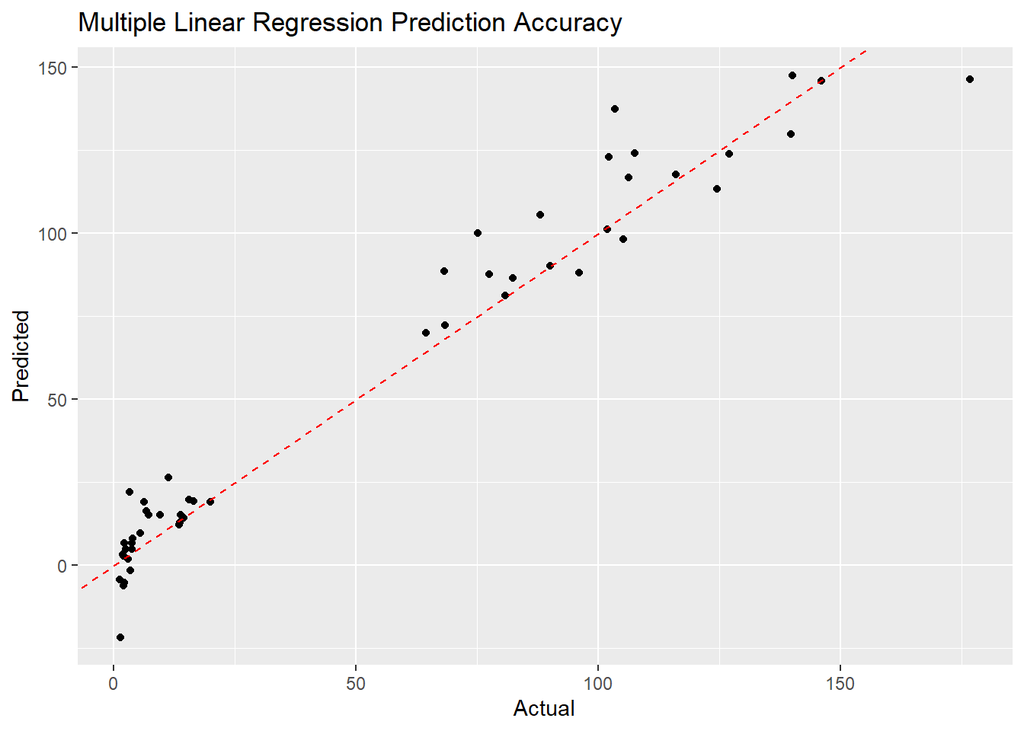

```
## Average (LFW):  51.5752
```

```
## Standard deviation (LFW)):  52.49733
```

```
## R-squared:  0.9562656
```

```
## RMSE (Prediction):  11.44245
```

### Check model performance on different harvest dates:

#### First Harvest Day:

The issue with the prediction is that we are fitting a global model that includes biomass quantification during previous days. This implies that we must run our prediction on filtered data sets by date of harvest to assess the model performance.

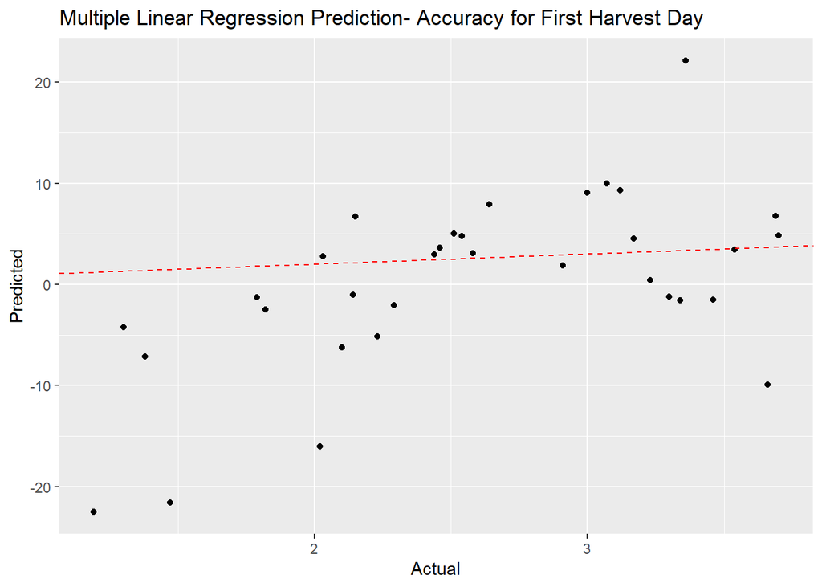

```
## Average (LFW):  2.594848
```

```
## Standard deviation (LFW)):  0.7406421
```

```
## R-squared:  0.3132308
```

```
## RMSE (Prediction):  8.733471
```

The issue with the prediction is that we are fitting a global model that includes biomass quantification during previous days. This implies that we must run our prediction on filtered data sets by date of harvest to assess the model performance.

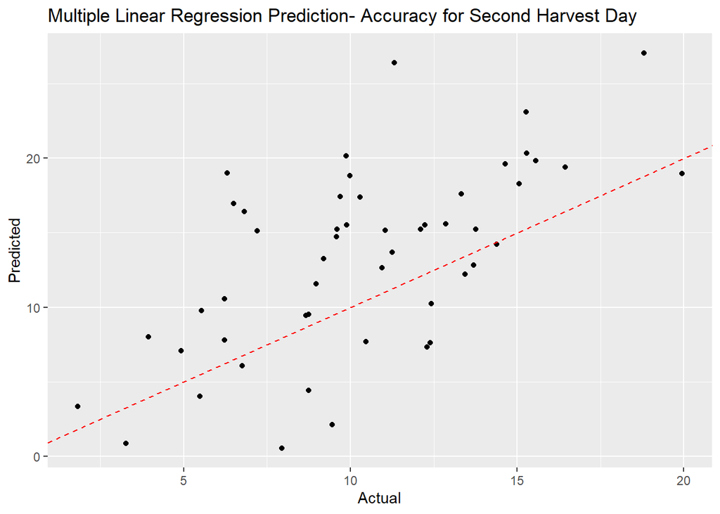

```
## Average (LFW):  10.40529
```

```
## Standard deviation (LFW)):  3.905721
```

```
## R-squared:  0.3914177
```

```
## RMSE (Prediction):  5.626037
```

#### Last Harvest Day:

The issue with the prediction is that we are fitting a global model that includes biomass quantification during previous days. This implies that we must run our prediction on filtered data sets by date of harvest to assess the model performance.

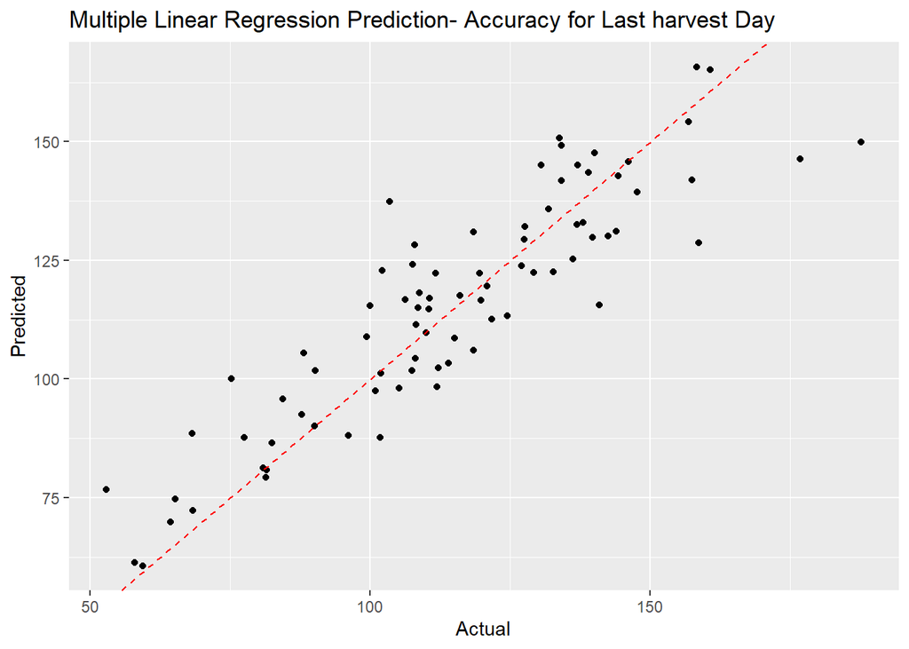

```
## Average (LFW):  114.5844
```

```
## Standard deviation (LFW)):  28.11278
```

```
## R-squared:  0.7999263
```

```
## RMSE (Prediction):  12.57902
```

### Fit Multiple Linear Model Using Normalized Data:

For normalization I’m using the standardization function from the package Bbmisc. With this I will make sure all predictors have the same weight.

Once again we will fit the model using a train and test proportion.

```
## Start:  AIC=939.57
## LFW_g ~ 1
##
##                              Df Sum of Sq    RSS    AIC
## + plant_ellipse_minor_axis    1    373234  26180 628.20
## + height_mm                   1    367079  32335 652.48
## + plant_height                1    338332  61081 725.63
## + plant_area                  1    338106  61308 726.05
## + plant_width                 1    323748  75665 750.25
## + plant_longest_path          1    306377  93037 774.02
## + plant_convex_hull_area      1    305550  93863 775.04
## + plant_ellipse_major_axis    1    299970  99444 781.68
## + plant_convex_hull_vertices  1    298209 101205 783.70
## + plant_perimeter             1    250912 148502 827.79
## + plant_solidity              1     41432 357982 928.98
## + plant_ellipse_eccentricity  1     30044 369370 932.58
## <none>                                    399414 939.57
## + plant_ellipse_angle         1         5 399409 941.57
##
## Step:  AIC=628.2
## LFW_g ~ plant_ellipse_minor_axis
##
##                              Df Sum of Sq   RSS    AIC
## + height_mm                   1   2067.73 24112 620.74
## + plant_ellipse_eccentricity  1   1154.71 25025 625.01
## + plant_ellipse_angle         1    687.62 25492 627.14
## + plant_area                  1    648.16 25532 627.31
## <none>                                    26180 628.20
## + plant_perimeter             1    425.59 25754 628.31
## + plant_height                1    408.43 25771 628.39
## + plant_solidity              1    291.47 25888 628.91
## + plant_convex_hull_vertices  1    204.71 25975 629.29
## + plant_convex_hull_area      1     80.56 26099 629.84
## + plant_ellipse_major_axis    1     30.21 26149 630.06
## + plant_width                 1     26.89 26153 630.08
## + plant_longest_path          1     18.39 26161 630.12
##
## Step:  AIC=620.74
## LFW_g ~ plant_ellipse_minor_axis + height_mm
##
```

[output cut: 58 more lines]

```
## + plant_height                1      1.06 10824 536.63
##
## Step:  AIC=532.05
## LFW_g ~ plant_ellipse_minor_axis + height_mm + plant_area + plant_ellipse_major_axis +
##     plant_ellipse_eccentricity + plant_solidity
##
##                              Df Sum of Sq   RSS    AIC
## <none>                                    10402 532.05
## + plant_longest_path          1    93.671 10308 533.01
## + plant_perimeter             1    17.957 10384 533.85
## + plant_convex_hull_area      1    16.784 10385 533.86
## + plant_convex_hull_vertices  1     4.098 10398 534.00
## + plant_width                 1     3.941 10398 534.01
## + plant_height                1     1.539 10400 534.03
## + plant_ellipse_angle         1     0.007 10402 534.05
```

```
##
## Call:
## lm(formula = LFW_g ~ plant_ellipse_minor_axis + height_mm + plant_area +
##     plant_ellipse_major_axis + plant_ellipse_eccentricity + plant_solidity,
##     data = train_set_std)
##
## Residuals:
##     Min      1Q  Median      3Q     Max
## -23.825  -5.459  -1.383   4.463  37.693
##
## Coefficients:
##                            Estimate Std. Error t value Pr(>|t|)
## (Intercept)                 -21.530      7.578  -2.841 0.005377 **
## plant_ellipse_minor_axis     24.222     24.198   1.001 0.319076
## height_mm                   125.807     16.683   7.541 1.54e-11 ***
## plant_area                  424.687     39.363  10.789  < 2e-16 ***
## plant_ellipse_major_axis   -414.223     38.677 -10.710  < 2e-16 ***
## plant_ellipse_eccentricity   25.738      6.618   3.889 0.000174 ***
## plant_solidity              -15.029      7.169  -2.096 0.038382 *
## ---
## Signif. codes:  0 '***' 0.001 '**' 0.01 '*' 0.05 '.' 0.1 ' ' 1
##
## Residual standard error: 9.814 on 108 degrees of freedom
## Multiple R-squared:  0.974,  Adjusted R-squared:  0.9725
## F-statistic: 673.2 on 6 and 108 DF,  p-value: < 2.2e-16
```

The issue with the prediction is that we are fitting a global model that includes biomass quantification during previous days. This implies that we must run our prediction on datasets filtered by data to assess the model performance.

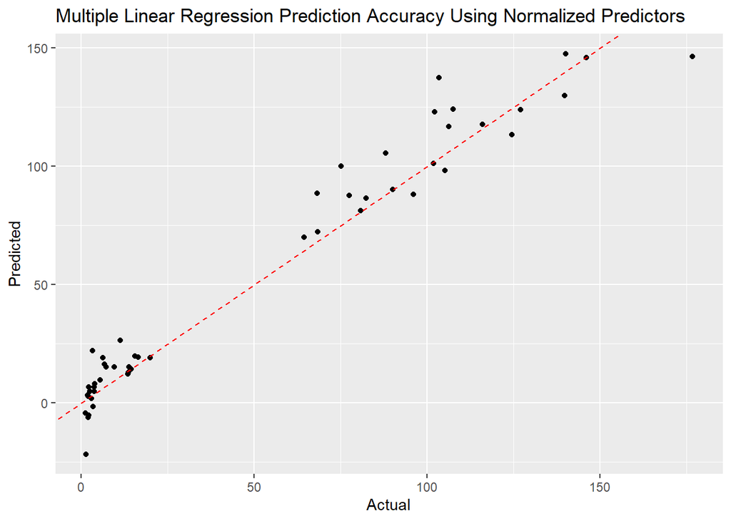

```
## Average (LFW):  51.5752
```

```
## Standard deviation (LFW)):  52.49733
```

```
## R-squared:  0.9562656
```

```
## RMSE (Prediction):  11.44245
```

#### First Harvest Day:

The issue with the prediction is that we are fitting a global model that includes biomass quantification during previous days. This implies that we must run our prediction on filtered data sets by date of harvest to assess the model performance.

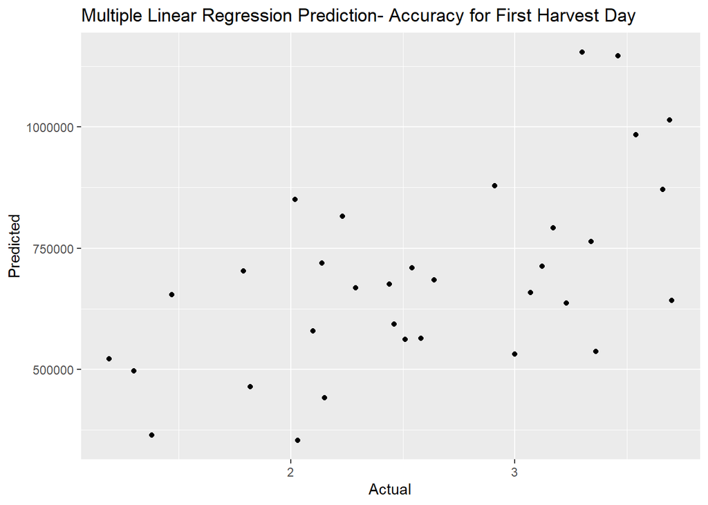

```
## Average (LFW):  2.594848
```

```
## Standard deviation (LFW)):  0.7406421
```

```
## R-squared:  0.350419
```

```
## RMSE (Prediction):  716146.1
```

### Estimation of Leaf Dry Weight (LDW)

```
## Start:  AIC=316.6
## LDW_g ~ 1
##
##                              Df Sum of Sq     RSS     AIC
## + plant_ellipse_minor_axis    1   1046.42   64.13 -151.94
## + height_mm                   1   1028.79   81.76 -111.86
## + plant_height                1    971.92  138.63  -24.74
## + plant_area                  1    965.40  145.14  -17.16
## + plant_width                 1    915.64  194.91   31.48
## + plant_convex_hull_area      1    890.41  220.14   51.57
## + plant_longest_path          1    878.47  232.07   60.28
## + plant_ellipse_major_axis    1    872.22  238.33   64.67
## + plant_convex_hull_vertices  1    856.43  254.12   75.25
## + plant_perimeter             1    744.78  365.76  135.35
## + plant_solidity              1    126.37  984.17  298.67
## + plant_ellipse_eccentricity  1    104.86 1005.68  302.23
## <none>                                    1110.55  316.60
## + plant_ellipse_angle         1      0.02 1110.52  318.60
##
## Step:  AIC=-151.94
## LDW_g ~ plant_ellipse_minor_axis
##
##                              Df Sum of Sq    RSS     AIC
## + height_mm                   1    7.0160 57.111 -169.06
## + plant_area                  1    2.3381 61.789 -156.07
## + plant_ellipse_eccentricity  1    1.9820 62.145 -155.12
## + plant_solidity              1    1.7167 62.410 -154.42
## <none>                                    64.127 -151.94
## + plant_perimeter             1    0.7399 63.387 -151.85
## + plant_convex_hull_area      1    0.5381 63.589 -151.33
## + plant_height                1    0.2793 63.848 -150.66
## + plant_ellipse_angle         1    0.2584 63.868 -150.60
## + plant_width                 1    0.1619 63.965 -150.36
## + plant_convex_hull_vertices  1    0.0983 64.028 -150.19
## + plant_longest_path          1    0.0635 64.063 -150.10
## + plant_ellipse_major_axis    1    0.0465 64.080 -150.06
##
## Step:  AIC=-169.06
## LDW_g ~ plant_ellipse_minor_axis + height_mm
##
```

[output cut: 58 more lines]

```
## + plant_ellipse_angle         1   0.00653 28.534 -275.55
##
## Step:  AIC=-281.52
## LDW_g ~ plant_ellipse_minor_axis + height_mm + plant_area + plant_ellipse_major_axis +
##     plant_ellipse_eccentricity + plant_convex_hull_area
##
##                              Df Sum of Sq    RSS     AIC
## <none>                                    27.520 -281.52
## + plant_longest_path          1  0.194459 27.326 -280.69
## + plant_convex_hull_vertices  1  0.081319 27.439 -280.01
## + plant_height                1  0.033745 27.486 -279.72
## + plant_width                 1  0.031304 27.489 -279.71
## + plant_solidity              1  0.029235 27.491 -279.69
## + plant_perimeter             1  0.014806 27.505 -279.61
## + plant_ellipse_angle         1  0.004090 27.516 -279.54
```

```
##
## Call:
## lm(formula = LDW_g ~ plant_ellipse_minor_axis + height_mm + plant_area +
##     plant_ellipse_major_axis + plant_ellipse_eccentricity + plant_convex_hull_area,
##     data = img_LDW)
##
## Residuals:
##      Min       1Q   Median       3Q      Max
## -1.13773 -0.21536 -0.04213  0.22753  1.51628
##
## Coefficients:
##                              Estimate Std. Error t value Pr(>|t|)
## (Intercept)                -2.309e+00  3.209e-01  -7.195 2.36e-11 ***
## plant_ellipse_minor_axis    2.008e-02  5.085e-03   3.948 0.000118 ***
## height_mm                   3.174e-01  3.462e-02   9.170 2.43e-16 ***
## plant_area                  1.460e-04  4.017e-05   3.634 0.000377 ***
## plant_ellipse_major_axis   -4.037e-02  4.370e-03  -9.238  < 2e-16 ***
## plant_ellipse_eccentricity  2.104e+00  4.375e-01   4.808 3.53e-06 ***
## plant_convex_hull_area      8.724e-05  3.605e-05   2.420 0.016648 *
## ---
## Signif. codes:  0 '***' 0.001 '**' 0.01 '*' 0.05 '.' 0.1 ' ' 1
##
## Residual standard error: 0.4173 on 158 degrees of freedom
## Multiple R-squared:  0.9752, Adjusted R-squared:  0.9743
## F-statistic:  1036 on 6 and 158 DF,  p-value: < 2.2e-16
```

### Estimation of Leaf Area (LA)

Notice that for Leaf Area(LA) we are including both LFW and LDW as predictors.

```
## Start:  AIC=2145.46
## LA_mm2 ~ 1
##
##                              Df Sum of Sq      RSS    AIC
## + LDW_g                       1  72167588   151587 1129.8
## + LFW_g                       1  72028689   290486 1237.1
## + plant_ellipse_minor_axis    1  67685392  4633782 1694.1
## + height_mm                   1  67015000  5304175 1716.4
## + plant_height                1  62728369  9590806 1814.1
## + plant_area                  1  62414450  9904724 1819.4
## + plant_width                 1  58987963 13331211 1868.5
## + plant_convex_hull_area      1  57462148 14857027 1886.3
## + plant_longest_path          1  56605612 15713563 1895.6
## + plant_ellipse_major_axis    1  56220730 16098445 1899.6
## + plant_convex_hull_vertices  1  55547596 16771578 1906.3
## + plant_perimeter             1  47744139 24575036 1969.4
## + plant_solidity              1   8378844 63940331 2127.1
## + plant_ellipse_eccentricity  1   6737185 65581989 2131.3
## <none>                                    72319175 2145.5
## + plant_ellipse_angle         1      3611 72315563 2147.4
##
## Step:  AIC=1129.79
## LA_mm2 ~ LDW_g
##
##                              Df Sum of Sq    RSS    AIC
## + LFW_g                       1   27808.3 123779 1098.3
## + plant_perimeter             1    6769.5 144817 1124.2
## + plant_width                 1    6348.9 145238 1124.7
## + plant_ellipse_minor_axis    1    6331.7 145255 1124.8
## + plant_height                1    5902.0 145685 1125.2
## + plant_longest_path          1    4870.4 146716 1126.4
## + plant_ellipse_major_axis    1    4358.1 147229 1127.0
## + plant_convex_hull_area      1    3501.1 148086 1127.9
## + plant_area                  1    3153.5 148433 1128.3
## <none>                                    151587 1129.8
## + height_mm                   1    1304.3 150283 1130.4
## + plant_solidity              1     943.6 150643 1130.8
## + plant_ellipse_angle         1     428.3 151159 1131.3
## + plant_ellipse_eccentricity  1     242.8 151344 1131.5
## + plant_convex_hull_vertices  1     223.0 151364 1131.5
```

[output cut: 55 more lines]

```
## Step:  AIC=1070.81
## LA_mm2 ~ LDW_g + LFW_g + height_mm + plant_width + plant_ellipse_eccentricity
##
##                              Df Sum of Sq    RSS    AIC
## <none>                                    101013 1070.8
## + plant_area                  1    757.23 100256 1071.6
## + plant_convex_hull_area      1    668.04 100345 1071.7
## + plant_ellipse_major_axis    1    166.49 100846 1072.5
## + plant_solidity              1    104.29 100909 1072.6
## + plant_ellipse_angle         1     67.79 100945 1072.7
## + plant_convex_hull_vertices  1     66.36 100947 1072.7
## + plant_ellipse_minor_axis    1     10.55 101002 1072.8
## + plant_longest_path          1      9.98 101003 1072.8
## + plant_height                1      0.02 101013 1072.8
## + plant_perimeter             1      0.01 101013 1072.8
```

```
##
## Call:
## lm(formula = LA_mm2 ~ LDW_g + LFW_g + height_mm + plant_width +
##     plant_ellipse_eccentricity, data = img_LA)
##
## Residuals:
##     Min      1Q  Median      3Q     Max
## -81.495 -12.255  -0.243   9.896  86.083
##
## Coefficients:
##                             Estimate Std. Error t value Pr(>|t|)
## (Intercept)                -60.00330   17.40026  -3.448 0.000722 ***
## LDW_g                      153.26639   14.36495  10.669  < 2e-16 ***
## LFW_g                        4.17347    0.57286   7.285 1.41e-11 ***
## height_mm                   10.69542    1.89320   5.649 7.26e-08 ***
## plant_width                 -0.28911    0.08007  -3.611 0.000409 ***
## plant_ellipse_eccentricity  33.64113   16.32306   2.061 0.040936 *
## ---
## Signif. codes:  0 '***' 0.001 '**' 0.01 '*' 0.05 '.' 0.1 ' ' 1
##
## Residual standard error: 25.21 on 159 degrees of freedom
## Multiple R-squared:  0.9986, Adjusted R-squared:  0.9986
## F-statistic: 2.274e+04 on 5 and 159 DF,  p-value: < 2.2e-16
```